# **Project 2 – CNN & Transfer Learning for Medical Image Classification**

#### Group 12 | Shirley Liu, Sofia Giorgianni & William Wang

#### November 14th, 2025

#### https://github.com/CyberSnorlax/GR5074-Project-2-Group-12

# **1. Dataset and Exploratory Data Analysis**

```python
# Loading libraries and downloading data

import sys
import time
import cv2
import numpy as np
from matplotlib import pyplot as plt
import tensorflow as tf
import zipfile
import os, shutil, glob

from sklearn.model_selection import train_test_split

from tensorflow.python.keras.utils import np_utils
from tensorflow.keras.models import Sequential, Model
from tensorflow.keras.layers import Dense, Dropout, Flatten, Activation, BatchNormalization
from tensorflow.python.keras.layers.convolutional import Conv2D, MaxPooling2D
from tensorflow.keras.preprocessing.image import ImageDataGenerator
from tensorflow.keras.optimizers import Adam,SGD,Adagrad,Adadelta,RMSprop
from tensorflow.keras.applications import VGG19, ResNet50, InceptionV3
from tensorflow import keras
from tensorflow.keras import layers, callbacks, applications
from collections import Counter
from sklearn.metrics import classification_report, confusion_matrix

# Inspect available datasets
!ls /kaggle/input
```

[output not shown]

[output not shown]

[output not shown]

[output not shown]

[output not shown]

[output not shown]

```
covid19-radiography-database
```

```python
DATA_ROOT = "/kaggle/input/covid19-radiography-database"
!ls "$DATA_ROOT"
```

```
COVID-19_Radiography_Dataset
```

```python
DATA_DIR = "/kaggle/input/covid19-radiography-database/COVID-19_Radiography_Dataset"
!ls "$DATA_DIR"
```

```
 COVID			      Normal.metadata.xlsx
 COVID.metadata.xlsx	      README.md.txt
 Lung_Opacity		     'Viral Pneumonia'
 Lung_Opacity.metadata.xlsx  'Viral Pneumonia.metadata.xlsx'
 Normal
```

```python
# Connecting to Google Drive

# import os
# from google.colab import drive
# drive.mount('/content/drive')
```

**Start by describing the dataset.** Include basic statistics and image samples to show the types of images available (e.g., COVID-positive and negative chest x-rays).

```python
import os

DATA_DIR = "/kaggle/input/covid19-radiography-database/COVID-19_Radiography_Dataset"
categories = ["COVID", "Normal", "Viral Pneumonia", "Lung_Opacity"]

image_counts = {}
for category in categories:
    folder_path = os.path.join(DATA_DIR, category, "images")  # <-- IMPORTANT
    print("Checking folder:", folder_path)
    num_images = len([
        f for f in os.listdir(folder_path)
        if f.lower().endswith((".png", ".jpg", ".jpeg"))
    ])
    image_counts[category] = num_images

image_counts
```

```
Checking folder: /kaggle/input/covid19-radiography-database/COVID-19_Radiography_Dataset/COVID/images
Checking folder: /kaggle/input/covid19-radiography-database/COVID-19_Radiography_Dataset/Normal/images
Checking folder: /kaggle/input/covid19-radiography-database/COVID-19_Radiography_Dataset/Viral Pneumonia/images
Checking folder: /kaggle/input/covid19-radiography-database/COVID-19_Radiography_Dataset/Lung_Opacity/images
```

```
{'COVID': 3616, 'Normal': 10192, 'Viral Pneumonia': 1345, 'Lung_Opacity': 6012}
```

This dataset contains a total of 21,165 X-ray images, divided into **four** distinct categories:

1. Covid (3616 images)
2. Normal (10,192 images)
3. Viral Pneumonia (1,345 images)
4. Lung Opacity (6,012 images)

```
Total images collected: 21165
```

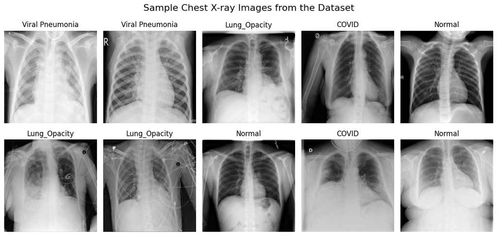

```python
# Extracting image samples from each class

import matplotlib.pyplot as plt
import matplotlib.image as mpimg

# Build lists of (image_path, label)
image_paths = []
labels = []

for cat in categories:
    folder = os.path.join(DATA_DIR, cat, "images")  # <--- changed from base_path/cat to DATA_DIR/cat/images
    print("Collecting from:", folder)
    images = [
        f for f in os.listdir(folder)
        if f.lower().endswith((".png", ".jpg", ".jpeg"))
    ]
    for img in images:
        image_paths.append(os.path.join(folder, img))
        labels.append(cat)

# Convert to arrays (for random indexing)
X_paths = np.array(image_paths)
y_labels = np.array(labels)

print("Total images collected:", len(y_labels))

# Guard in case something is still wrong
if len(y_labels) == 0:
    print("No images found. Check DATA_DIR, categories, and folder structure.")
else:
    # Randomly pick samples
    fig, ax = plt.subplots(2, 5, figsize=(12, 6))
    for i in range(2):
        for j in range(5):
            idx = np.random.randint(0, len(y_labels))
            img = mpimg.imread(X_paths[idx])
            ax[i, j].imshow(img, cmap="gray")
            ax[i, j].set_title(f"{y_labels[idx]}")
            ax[i, j].axis("off")

    plt.suptitle("Sample Chest X-ray Images from the Dataset", fontsize=16)
    plt.tight_layout()
    plt.show()
```

**Check if the dataset is balanced across classes.** If it's imbalanced:

- Discuss potential strategies such as class weighting, oversampling,

undersampling, or augmentation.

- Indicate **which method you chose**, and discuss **how model

performance** changed as a result.

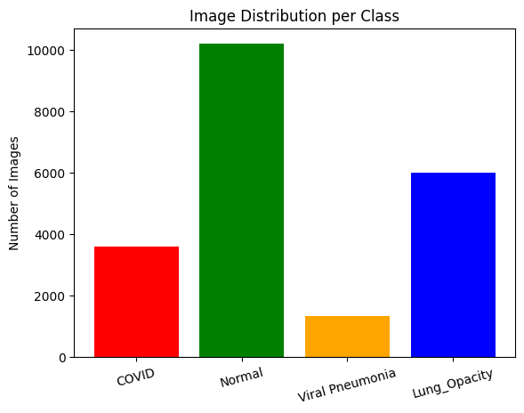

```python
# Checking if dataset is balanced across classes

plt.bar(image_counts.keys(), image_counts.values(), color=['red','green','orange','blue'])
plt.title("Image Distribution per Class")
plt.ylabel("Number of Images")
plt.xticks(rotation=15)
plt.show()
```

- The dataset is **heavily imbalanced** as seen in the bar chart displayed above. The 'Normal image' class is the majority class, representing almost half of the sample. It is important to address this imbalance before moving on with deep learning as the imbalance may introduce bias to the model.
- We will implement **data augmentation** and **class weighting** to address this imbalance. Data augmentation increases the diversity of training samples for minority classes by applying random transformations, helping the model generalize better. Class weighting adjusts the loss function so that errors on minority classes are penalized more heavily, ensuring the model learns from all categories fairly without discarding valuable data.

**To study the impact of imbalance on model performance, we trained two versions of the model:**

```python
# Configuration (Kaggle)

RAW_DATA_DIR = "/kaggle/input/covid19-radiography-database/COVID-19_Radiography_Dataset"
CATEGORIES   = ["COVID", "Normal", "Viral Pneumonia", "Lung_Opacity"]

IMG_SIZE   = (128, 128)
BATCH_SIZE = 32
SEED       = 42
AUTOTUNE   = tf.data.AUTOTUNE
```

```python
# Augmentation & Normalization

## Normalization scales pixel values
norm = layers.Rescaling(1./255)

## Augmentation randomly modifies images during training
augment = keras.Sequential(
    [
        layers.RandomFlip("horizontal"),
        layers.RandomRotation(0.08),
        layers.RandomZoom(0.1),
    ],
    name="augment",
)
```

[output not shown]

```python
def make_datasets(data_dir=DATA_DIR, img_size=IMG_SIZE, batch_size=BATCH_SIZE, seed=SEED):
    """
    Loads images from folders, splits into 80% training, 10% validation, 10% testing.
    Applies normalization to all sets, and augmentation only to training.
    """

    # Putting 80% of images in training
    train_raw = keras.utils.image_dataset_from_directory(
        data_dir,
        validation_split=0.2,
        subset="training",
        seed=seed,
        image_size=img_size,
        batch_size=batch_size,
    )

    # Using 20% left for validation & test
    valtest_raw = keras.utils.image_dataset_from_directory(
        data_dir,
        validation_split=0.2,
        subset="validation",
        seed=seed,
        image_size=img_size,
        batch_size=batch_size,
    )

    # Splitting the 20% into 10% val & 10% test
    card = tf.data.experimental.cardinality(valtest_raw).numpy()
    val_raw  = valtest_raw.take(card // 2)
    test_raw = valtest_raw.skip(card // 2)

    def prep_train(x, y): return augment(norm(x), training=True), y
    def prep_eval(x, y):  return norm(x), y

    train = train_raw.shuffle(512).map(prep_train, num_parallel_calls=AUTOTUNE).prefetch(AUTOTUNE)
    val   = val_raw.map(prep_eval,   num_parallel_calls=AUTOTUNE).prefetch(AUTOTUNE)
    test  = test_raw.map(prep_eval,  num_parallel_calls=AUTOTUNE).prefetch(AUTOTUNE)

    return train, val, test, train_raw.class_names
```

```python
def compute_class_weight_from_dir(data_dir, class_names, train_frac=0.8):
    import math

    counts_total = {}
    for i, cls in enumerate(class_names):
        folder = os.path.join(data_dir, cls)  # images directly inside
        n = sum(f.lower().endswith((".png", ".jpg", ".jpeg")) for f in os.listdir(folder))
        counts_total[i] = n

    counts_train = {i: max(1, math.floor(n * train_frac)) for i, n in counts_total.items()}

    K = len(counts_train)
    N = sum(counts_train.values())
    class_weight = {i: float(N / (K * n_i)) for i, n_i in counts_train.items()}
    return class_weight
```

```python
# Building the Model

def make_mobilenet_model(num_classes, img_size=IMG_SIZE, lr=1e-4):
    """
    Creates lightweight CNN model using transfer learning from MobileNetV2.
    - Uses pretrained ImageNet weights
    - Adds small custom classification head
    """
    base = applications.MobileNetV2(include_top=False, weights="imagenet",
                                    input_shape=img_size + (3,))
    base.trainable = False

    # Defining model architecture
    inp = layers.Input(shape=img_size + (3,))
    x = keras.applications.mobilenet_v2.preprocess_input(inp)
    x = base(x, training=False)
    x = layers.GlobalAveragePooling2D()(x)
    x = layers.Dense(128, activation="relu")(x)
    x = layers.Dropout(0.3)(x)
    out = layers.Dense(num_classes, activation="softmax")(x)
    model = keras.Model(inp, out)
    model.compile(optimizer=keras.optimizers.Adam(lr),
                  loss="sparse_categorical_crossentropy",
                  metrics=["accuracy"])
    return model
```

```python
# Model Evaluation

def evaluate_to_text(tag, model, test_ds, class_names):
    """
    Evaluates trained model on test set.
    Prints: accuracy, classification report, and confusion matrix.
    """

    # Evaluating test performance
    test_loss, test_acc = model.evaluate(test_ds, verbose=0)
    print(f"[{tag}] Test accuracy: {test_acc:.4f}")

    # Converting dataset tensors to numpy arrays
    y_true = np.concatenate([y.numpy() for _, y in test_ds.unbatch().batch(2048)])
    y_prob = model.predict(test_ds, verbose=0)
    y_pred = y_prob.argmax(axis=1)

    # Extracting metrics
    print(f"\n[{tag}] Classification report (TEST):")
    print(classification_report(y_true, y_pred, target_names=class_names, zero_division=0))
    print(f"[{tag}] Confusion matrix (TEST):")
    print(confusion_matrix(y_true, y_pred))
    return test_acc
```

```python
# Defining Callback for Early Stopping

es   = callbacks.EarlyStopping(monitor="val_loss", patience=3,
                               restore_best_weights=True, verbose=1)
```

```python
# Experiment Runner (Main Function)

def run_experiment(tag, use_class_weight=False, epochs=5, lr=1e-4):
    """
    Runs full training cycle.
    - 'use_class_weight=False': imbalanced baseline
    - 'use_class_weight=True': balanced (augmentation + weights)
    """

    # Building datasets and model
    train_ds, val_ds, test_ds, class_names = make_datasets()
    model = make_mobilenet_model(len(class_names), lr=lr)

    cw = None
    if use_class_weight:
        cw = compute_class_weight_from_dir(DATA_DIR, class_names)
        print("Class weights:", cw)

    # Training model
    history = model.fit(
        train_ds,
        validation_data=val_ds,
        epochs=epochs,
        class_weight=cw,
        callbacks=[es],
        verbose=1
    )

    # Evaluating results on test data
    acc = evaluate_to_text(tag, model, test_ds, class_names)
    return {"tag": tag, "history": history.history, "test_acc": acc}
```

```python
# Model 1 — Imbalanced baseline (no class weights)

results_imbal = run_experiment("Imbalanced Baseline",
                               use_class_weight=False, epochs=5)
```

```
Found 42330 files belonging to 4 classes.
Using 33864 files for training.
Found 42330 files belonging to 4 classes.
Using 8466 files for validation.
Downloading data from https://storage.googleapis.com/tensorflow/keras-applications/mobilenet_v2/mobilenet_v2_weights_tf_dim_ordering_tf_kernels_1.0_128_no_top.h5
9406464/9406464 ━━━━━━━━━━━━━━━━━━━━ 0s 0us/step
```

[output not shown]

```
   7/1059 ━━━━━━━━━━━━━━━━━━━━ 29s 28ms/step - accuracy: 0.2491 - loss: 1.8195
```

```
I0000 00:00:1763039441.106804     117 device_compiler.h:188] Compiled cluster using XLA!  This line is logged at most once for the lifetime of the process.
```

```
1059/1059 ━━━━━━━━━━━━━━━━━━━━ 151s 92ms/step - accuracy: 0.4450 - loss: 1.2598 - val_accuracy: 0.4718 - val_loss: 1.1913
1059/1059 ━━━━━━━━━━━━━━━━━━━━ 71s 56ms/step - accuracy: 0.4848 - loss: 1.1903 - val_accuracy: 0.4735 - val_loss: 1.1877
1059/1059 ━━━━━━━━━━━━━━━━━━━━ 72s 57ms/step - accuracy: 0.4814 - loss: 1.1849 - val_accuracy: 0.4728 - val_loss: 1.1847
1059/1059 ━━━━━━━━━━━━━━━━━━━━ 71s 56ms/step - accuracy: 0.4780 - loss: 1.1854 - val_accuracy: 0.4728 - val_loss: 1.1773
1059/1059 ━━━━━━━━━━━━━━━━━━━━ 69s 54ms/step - accuracy: 0.4866 - loss: 1.1765 - val_accuracy: 0.4751 - val_loss: 1.1687
Restoring model weights from the end of the best epoch: 5.
[Imbalanced Baseline] Test accuracy: 0.4818

[Imbalanced Baseline] Classification report (TEST):
                 precision    recall  f1-score   support

          COVID       0.00      0.00      0.00       724
   Lung_Opacity       0.00      0.00      0.00      1192
         Normal       0.48      1.00      0.65      2052
Viral Pneumonia       0.00      0.00      0.00       274

       accuracy                           0.48      4242
      macro avg       0.12      0.25      0.16      4242
   weighted avg       0.23      0.48      0.32      4242

[Imbalanced Baseline] Confusion matrix (TEST):
[[   0    0  724    0]
 [   0    0 1192    0]
 [   0    0 2052    0]
 [   0    0  274    0]]
```

```python
# Model 2 - Balanced method (augmentation + class weighting)

results_bal   = run_experiment("Aug+ClassWeight (Full Data)",
                               use_class_weight=True, epochs=5)
```

```
Found 42330 files belonging to 4 classes.
Using 33864 files for training.
Found 42330 files belonging to 4 classes.
Using 8466 files for validation.
Class weights: {0: 1.0, 1: 1.0, 2: 1.0, 3: 1.0}
1059/1059 ━━━━━━━━━━━━━━━━━━━━ 83s 59ms/step - accuracy: 0.4466 - loss: 1.2550 - val_accuracy: 0.4718 - val_loss: 1.1934
1059/1059 ━━━━━━━━━━━━━━━━━━━━ 72s 55ms/step - accuracy: 0.4823 - loss: 1.1940 - val_accuracy: 0.4735 - val_loss: 1.1898
1059/1059 ━━━━━━━━━━━━━━━━━━━━ 73s 56ms/step - accuracy: 0.4821 - loss: 1.1915 - val_accuracy: 0.4728 - val_loss: 1.1862
1059/1059 ━━━━━━━━━━━━━━━━━━━━ 71s 55ms/step - accuracy: 0.4820 - loss: 1.1851 - val_accuracy: 0.4728 - val_loss: 1.1858
1059/1059 ━━━━━━━━━━━━━━━━━━━━ 70s 55ms/step - accuracy: 0.4793 - loss: 1.1863 - val_accuracy: 0.4751 - val_loss: 1.1762
Restoring model weights from the end of the best epoch: 5.
[Aug+ClassWeight (Full Data)] Test accuracy: 0.4818

[Aug+ClassWeight (Full Data)] Classification report (TEST):
                 precision    recall  f1-score   support

          COVID       0.00      0.00      0.00       724
   Lung_Opacity       0.00      0.00      0.00      1192
         Normal       0.48      1.00      0.65      2052
Viral Pneumonia       0.00      0.00      0.00       274

       accuracy                           0.48      4242
      macro avg       0.12      0.25      0.16      4242
   weighted avg       0.23      0.48      0.32      4242

[Aug+ClassWeight (Full Data)] Confusion matrix (TEST):
[[   0    0  724    0]
 [   0    0 1192    0]
 [   0    0 2052    0]
 [   0    0  274    0]]
```

**Reflect on the practical value of this classification task. Who might benefit from your model in a real-world setting?**

- This classification task is valuable in the medical field, especially for doctors and radiologists who analyze chest X-rays. An automated model like this can serve as a decision-support tool, helping doctors quickly screen large numbers of X-ray images and prioritize potentially abnormal cases such as COVID-19 or pneumonia. While not a replacement for professional diagnosis, it can serve as a useful decision-support tool in clinical settings.

# **2. Baseline CNN Model**

Build and train a **basic Convolutional Neural Network (CNN)** to serve as a **baseline**.

```python
train_ds, val_ds, test_ds, class_names = make_datasets(DATA_DIR)
num_classes = len(class_names)

# Normalized datasets for baseline CNN
norm_only = lambda x, y: (x / 255.0, y)
train_baseline = train_ds.map(norm_only)
val_baseline   = val_ds.map(norm_only)
test_baseline  = test_ds.map(norm_only)
```

```
Found 42330 files belonging to 4 classes.
Using 33864 files for training.
Found 42330 files belonging to 4 classes.
Using 8466 files for validation.
```

```python
# Building CNN model

def build_baseline_cnn(input_shape, num_classes):
    inputs = keras.layers.Input(shape=input_shape)

    x = keras.layers.Conv2D(32, 3, padding="same", use_bias=False)(inputs)
    x = keras.layers.BatchNormalization()(x); x = keras.layers.ReLU()(x)
    x = keras.layers.MaxPool2D()(x)

    x = keras.layers.Conv2D(64, 3, padding="same", use_bias=False)(x)
    x = keras.layers.BatchNormalization()(x); x = keras.layers.ReLU()(x)
    x = keras.layers.MaxPool2D()(x)

    x = keras.layers.Conv2D(128, 3, padding="same", use_bias=False)(x)
    x = keras.layers.BatchNormalization()(x); x = keras.layers.ReLU()(x)
    x = keras.layers.MaxPool2D()(x)

    x = keras.layers.Conv2D(128, 3, padding="same", use_bias=False)(x)
    x = keras.layers.BatchNormalization()(x); x = keras.layers.ReLU()(x)
    x = keras.layers.GlobalAveragePooling2D()(x)

    x = keras.layers.Dropout(0.4)(x)
    x = keras.layers.Dense(128, activation="relu")(x)
    x = keras.layers.Dropout(0.3)(x)
    outputs = keras.layers.Dense(num_classes, activation="softmax")(x)

    model = keras.Model(inputs, outputs)
    model.compile(
        optimizer=keras.optimizers.Adam(1e-3),
        loss="sparse_categorical_crossentropy",
        metrics=["accuracy"]
    )
    return model
```

**Clearly describe the architecture, loss function, optimizer, evaluation metrics, and training configuration.**

**Architecture**:

- 4 convolutional blocks with BatchNorm → ReLU; the first 3 use MaxPool to downsample; the last uses GlobalAveragePooling.
- Then Dropout(0.4) → Dense(128, ReLU) → Dropout(0.3) → Softmax(num_classes).

**Loss function:**

- `sparse_categorical_crossentropy`, which is suitable for integer-encoded class labels.

**Optimizer:**

- `Adam` with a learning rate of 1e-3, providing adaptive gradient updates for efficient convergence.

**Evaluation metrics:**

- Primary metric: `accuracy` during training and validation.
- After training, precision, recall, F1-score, and the confusion matrix are reported for a detailed performance breakdown across classes.

Report the model’s **training, validation, and test performance**.

The baseline CNN shows moderate learning and generalization, capturing key image features but still limited by class imbalance and the simplicity of the architecture.

```python
baseline = build_baseline_cnn(IMG_SIZE + (3,), num_classes)
es = keras.callbacks.EarlyStopping(monitor="val_loss", patience=3,
                                   restore_best_weights=True, verbose=1)
history = baseline.fit(
    train_baseline,
    validation_data=val_baseline,
    epochs=5,
    callbacks=[es],
    verbose=1
)

# Performance report

final_train_acc = history.history["accuracy"][-1]
final_val_acc   = history.history["val_accuracy"][-1]
print(f"\n[Baseline CNN] Final train acc: {final_train_acc:.4f} | Final val acc: {final_val_acc:.4f}")

test_loss, test_acc = baseline.evaluate(test_baseline, verbose=0)
print(f"[Baseline CNN] Test accuracy: {test_acc:.4f} | Test loss: {test_loss:.4f}")
```

```
1059/1059 ━━━━━━━━━━━━━━━━━━━━ 81s 58ms/step - accuracy: 0.5192 - loss: 1.1242 - val_accuracy: 0.6011 - val_loss: 0.9611
1059/1059 ━━━━━━━━━━━━━━━━━━━━ 71s 55ms/step - accuracy: 0.5896 - loss: 0.9584 - val_accuracy: 0.5601 - val_loss: 0.9704
1059/1059 ━━━━━━━━━━━━━━━━━━━━ 71s 55ms/step - accuracy: 0.6308 - loss: 0.8795 - val_accuracy: 0.4856 - val_loss: 1.2363
1059/1059 ━━━━━━━━━━━━━━━━━━━━ 69s 53ms/step - accuracy: 0.6603 - loss: 0.8230 - val_accuracy: 0.6345 - val_loss: 1.1848
Epoch 4: early stopping
Restoring model weights from the end of the best epoch: 1.

[Baseline CNN] Final train acc: 0.6688 | Final val acc: 0.6345
[Baseline CNN] Test accuracy: 0.6044 | Test loss: 0.9619
```

# **3. Transfer Learning with ResNet**

Implement **ResNet** using **transfer learning**.

```python
# Implementing ResNet using transfer learning
def build_resnet_transfer(num_classes, base_trainable=False, input_res=(224, 224)):
    inputs = keras.Input(shape=IMG_SIZE + (3,))  # Your dataset outputs IMG_SIZE
    x = layers.Resizing(input_res[0], input_res[1])(inputs)       # 128->224
    x = layers.Rescaling(scale=2.0, offset=-1.0)(x)               # [0,1] -> [-1,1] for ResNet

    base = ResNet50(weights="imagenet", include_top=False, input_shape=input_res + (3,))
    base.trainable = base_trainable  # freeze for initial transfer learning

    x = base(x)
    x = layers.GlobalAveragePooling2D()(x)
    x = layers.Dropout(0.3)(x)
    x = layers.Dense(256, activation="relu")(x)
    x = layers.Dropout(0.3)(x)
    outputs = layers.Dense(num_classes, activation="softmax")(x)

    model = keras.Model(inputs, outputs, name="resnet50_transfer")
    model.compile(
        optimizer=keras.optimizers.Adam(learning_rate=1e-4),
        loss="sparse_categorical_crossentropy",
        metrics=["accuracy"]
    )
    return model

resnet_tl = build_resnet_transfer(num_classes=num_classes, base_trainable=False)
resnet_tl.summary()
```

```
Downloading data from https://storage.googleapis.com/tensorflow/keras-applications/resnet/resnet50_weights_tf_dim_ordering_tf_kernels_notop.h5
94765736/94765736 ━━━━━━━━━━━━━━━━━━━━ 0s 0us/step
```

```
Model: "resnet50_transfer"
```

```
┏━━━━━━━━━━━━━━━━━━━━━━━━━━━━━━━━━┳━━━━━━━━━━━━━━━━━━━━━━━━┳━━━━━━━━━━━━━━━┓
┃ Layer (type)                    ┃ Output Shape           ┃       Param # ┃
┡━━━━━━━━━━━━━━━━━━━━━━━━━━━━━━━━━╇━━━━━━━━━━━━━━━━━━━━━━━━╇━━━━━━━━━━━━━━━┩
│ input_layer_6 (InputLayer)      │ (None, 128, 128, 3)    │             0 │
├─────────────────────────────────┼────────────────────────┼───────────────┤
│ resizing (Resizing)             │ (None, 224, 224, 3)    │             0 │
├─────────────────────────────────┼────────────────────────┼───────────────┤
│ rescaling_1 (Rescaling)         │ (None, 224, 224, 3)    │             0 │
├─────────────────────────────────┼────────────────────────┼───────────────┤
│ resnet50 (Functional)           │ (None, 7, 7, 2048)     │    23,587,712 │
├─────────────────────────────────┼────────────────────────┼───────────────┤
│ global_average_pooling2d_3      │ (None, 2048)           │             0 │
│ (GlobalAveragePooling2D)        │                        │               │
├─────────────────────────────────┼────────────────────────┼───────────────┤
│ dropout_4 (Dropout)             │ (None, 2048)           │             0 │
├─────────────────────────────────┼────────────────────────┼───────────────┤
│ dense_6 (Dense)                 │ (None, 256)            │       524,544 │
├─────────────────────────────────┼────────────────────────┼───────────────┤
│ dropout_5 (Dropout)             │ (None, 256)            │             0 │
├─────────────────────────────────┼────────────────────────┼───────────────┤
│ dense_7 (Dense)                 │ (None, 4)              │         1,028 │
└─────────────────────────────────┴────────────────────────┴───────────────┘
```

```
 Total params: 24,113,284 (91.98 MB)
```

```
 Trainable params: 525,572 (2.00 MB)
```

```
 Non-trainable params: 23,587,712 (89.98 MB)
```

**Fine-tune the model and compare its performance with the baseline CNN.**

```python
# Fine-tuning the model
# only train the classifier head

early_stop = keras.callbacks.EarlyStopping(
    monitor="val_loss", patience=3, restore_best_weights=True, verbose=1
)

history_tl = resnet_tl.fit(
    train_ds,
    validation_data=val_ds,
    epochs=5,
    callbacks=[early_stop],
    verbose=1
)
```

```
1059/1059 ━━━━━━━━━━━━━━━━━━━━ 137s 106ms/step - accuracy: 0.4363 - loss: 1.3024 - val_accuracy: 0.5365 - val_loss: 1.0473
1059/1059 ━━━━━━━━━━━━━━━━━━━━ 115s 97ms/step - accuracy: 0.5291 - loss: 1.0960 - val_accuracy: 0.5805 - val_loss: 1.0073
1059/1059 ━━━━━━━━━━━━━━━━━━━━ 115s 97ms/step - accuracy: 0.5514 - loss: 1.0546 - val_accuracy: 0.5758 - val_loss: 0.9984
1059/1059 ━━━━━━━━━━━━━━━━━━━━ 116s 98ms/step - accuracy: 0.5566 - loss: 1.0363 - val_accuracy: 0.6006 - val_loss: 0.9694
1059/1059 ━━━━━━━━━━━━━━━━━━━━ 116s 98ms/step - accuracy: 0.5678 - loss: 1.0172 - val_accuracy: 0.5966 - val_loss: 0.9731
Restoring model weights from the end of the best epoch: 4.
```

```python
# Evaluate model performance after initial transfer training

tl_test_loss, tl_test_acc = resnet_tl.evaluate(test_ds, verbose=0)
print(f"[ResNet TL (frozen)]  Test Accuracy = {tl_test_acc:.4f}  |  Loss = {tl_test_loss:.4f}")
```

```
[ResNet TL (frozen)]  Test Accuracy = 0.6061  |  Loss = 0.9468
```

```python
# Unfreeze a few top layers and train with a smaller learning rate
# Define helper to unfreeze top layers
from tensorflow.keras import layers

def unfreeze_top_layers(model, n_layers_to_unfreeze=40):
    """
    Unfreezes the last N layers of the ResNet base (excluding BatchNorm).
    """
    base = None
    for layer in model.layers:
        if "resnet50" in layer.name.lower():
            base = layer
            break
        if hasattr(layer, "layers"):
            for sub in layer.layers:
                if "resnet50" in sub.name.lower():
                    base = sub
                    break
    if base is None:
        raise ValueError("ResNet base not found.")

    # Freeze all layers first, then unfreeze the last N
    for layer in base.layers:
        layer.trainable = False
    for layer in base.layers[-n_layers_to_unfreeze:]:
        if not isinstance(layer, layers.BatchNormalization):
            layer.trainable = True

    return model
```

```python
# fine tune apply unfreezing, recompile, and fine-tune

from tensorflow import keras

# Apply the unfreeze
resnet_ft = unfreeze_top_layers(resnet_tl, n_layers_to_unfreeze=40)

# Recompile with a smaller learning rate and run_eagerly=True (to prevent tf.function errors)
resnet_ft.compile(
    optimizer=keras.optimizers.Adam(learning_rate=1e-5),
    loss="sparse_categorical_crossentropy",
    metrics=["accuracy"],
    run_eagerly=True,
)

# Early stopping for stability
early_stop_ft = keras.callbacks.EarlyStopping(
    monitor="val_loss", patience=3, restore_best_weights=True, verbose=1
)

# Fine-tune the model
history_ft = resnet_ft.fit(
    train_ds,
    validation_data=val_ds,
    epochs=5,
    callbacks=[early_stop_ft],
    verbose=1
)

# Evaluate after fine-tuning
ft_test_loss, ft_test_acc = resnet_ft.evaluate(test_ds, verbose=0)
print(f"[ResNet FT (unfrozen)] Test Accuracy = {ft_test_acc:.4f} | Loss = {ft_test_loss:.4f}")
```

```
1059/1059 ━━━━━━━━━━━━━━━━━━━━ 601s 553ms/step - accuracy: 0.5935 - loss: 0.9691 - val_accuracy: 0.6416 - val_loss: 0.8735
1059/1059 ━━━━━━━━━━━━━━━━━━━━ 606s 558ms/step - accuracy: 0.6518 - loss: 0.8319 - val_accuracy: 0.6631 - val_loss: 0.8062
1059/1059 ━━━━━━━━━━━━━━━━━━━━ 614s 564ms/step - accuracy: 0.6750 - loss: 0.7851 - val_accuracy: 0.6738 - val_loss: 0.7703
1059/1059 ━━━━━━━━━━━━━━━━━━━━ 614s 563ms/step - accuracy: 0.6889 - loss: 0.7576 - val_accuracy: 0.6764 - val_loss: 0.7525
1059/1059 ━━━━━━━━━━━━━━━━━━━━ 607s 559ms/step - accuracy: 0.6987 - loss: 0.7317 - val_accuracy: 0.6894 - val_loss: 0.7455
Restoring model weights from the end of the best epoch: 5.
[ResNet FT (unfrozen)] Test Accuracy = 0.6964 | Loss = 0.7266
```

```python
# Compare to baseline CNN
try:
    baseline_loss, baseline_acc = baseline.evaluate(test_ds, verbose=0)
    print(f"[Baseline CNN]  Test Accuracy = {baseline_acc:.4f}  |  Loss = {baseline_loss:.4f}")
except Exception:
    print("Baseline CNN metrics not found — run baseline cell first to compare.")

print("\nTest Accuracy Comparison")
try:
    print(f"Baseline CNN:   {baseline_acc:.4f}")
except:
    print("Baseline CNN:   (run baseline cell)")
print(f"ResNet TL:      {tl_test_acc:.4f}")
print(f"ResNet FT:      {ft_test_acc:.4f}")
```

```
[Baseline CNN]  Test Accuracy = 0.4863  |  Loss = 791.8271

Test Accuracy Comparison
Baseline CNN:   0.4863
ResNet TL:      0.6061
ResNet FT:      0.6964
```

**Discuss how using pre-trained features influences your model's training and generalization.**

# **4. Additional Architectures**

Implement **three additional models** of your choice.

Use consistent data splits and preprocessing across all models to ensure fair comparison.

```python
from tensorflow.keras.applications import VGG16
from tensorflow.keras import layers, Model, optimizers
from tensorflow import keras

def build_vgg16(num_classes, input_res=(224,224)):
    inputs = keras.Input(shape=IMG_SIZE + (3,))
    x = layers.Resizing(*input_res)(inputs)
    x = layers.Rescaling(2.0, offset=-1.0)(x)  # [0,1] -> [-1,1]

    base = VGG16(weights="imagenet", include_top=False, input_shape=input_res + (3,))
    base.trainable = False

    x = base(x)
    x = layers.GlobalAveragePooling2D()(x)
    x = layers.Dropout(0.3)(x)
    x = layers.Dense(256, activation="relu")(x)
    x = layers.Dropout(0.3)(x)
    outputs = layers.Dense(num_classes, activation="softmax")(x)
    model = Model(inputs, outputs, name="vgg16_transfer")
    model.compile(optimizer=optimizers.Adam(1e-4),
                  loss="sparse_categorical_crossentropy",
                  metrics=["accuracy"])
    return model

vgg16 = build_vgg16(num_classes)
es_vgg = keras.callbacks.EarlyStopping(monitor="val_loss", patience=3, restore_best_weights=True)
hist_vgg16 = vgg16.fit(train_ds, validation_data=val_ds, epochs=5, callbacks=[es_vgg], verbose=1)
vgg16_loss, vgg16_acc = vgg16.evaluate(test_ds, verbose=0)
print(f"[VGG16] Test Acc={vgg16_acc:.4f} | Loss={vgg16_loss:.4f}")
```

```
Downloading data from https://storage.googleapis.com/tensorflow/keras-applications/vgg16/vgg16_weights_tf_dim_ordering_tf_kernels_notop.h5
58889256/58889256 ━━━━━━━━━━━━━━━━━━━━ 0s 0us/step
1059/1059 ━━━━━━━━━━━━━━━━━━━━ 251s 210ms/step - accuracy: 0.4720 - loss: 1.1988 - val_accuracy: 0.5994 - val_loss: 0.9659
1059/1059 ━━━━━━━━━━━━━━━━━━━━ 230s 203ms/step - accuracy: 0.5873 - loss: 1.0034 - val_accuracy: 0.6383 - val_loss: 0.8768
1059/1059 ━━━━━━━━━━━━━━━━━━━━ 229s 203ms/step - accuracy: 0.6192 - loss: 0.9217 - val_accuracy: 0.6754 - val_loss: 0.8081
1059/1059 ━━━━━━━━━━━━━━━━━━━━ 229s 203ms/step - accuracy: 0.6420 - loss: 0.8806 - val_accuracy: 0.6799 - val_loss: 0.7961
1059/1059 ━━━━━━━━━━━━━━━━━━━━ 230s 203ms/step - accuracy: 0.6535 - loss: 0.8581 - val_accuracy: 0.6837 - val_loss: 0.7797
[VGG16] Test Acc=0.6898 | Loss=0.7739
```

```python
from tensorflow.keras.applications import InceptionV3
from tensorflow.keras import layers, Model, optimizers
from tensorflow import keras

def build_inceptionv3(num_classes, input_res=(224,224)):
    inputs = keras.Input(shape=IMG_SIZE + (3,))
    x = layers.Resizing(*input_res)(inputs)
    x = layers.Rescaling(2.0, offset=-1.0)(x)

    base = InceptionV3(weights="imagenet", include_top=False, input_shape=input_res + (3,))
    base.trainable = False

    x = base(x)
    x = layers.GlobalAveragePooling2D()(x)
    x = layers.Dropout(0.3)(x)
    x = layers.Dense(256, activation="relu")(x)
    x = layers.Dropout(0.3)(x)
    outputs = layers.Dense(num_classes, activation="softmax")(x)
    model = Model(inputs, outputs, name="inceptionv3_transfer")
    model.compile(optimizer=optimizers.Adam(1e-4),
                  loss="sparse_categorical_crossentropy",
                  metrics=["accuracy"])
    return model

incv3 = build_inceptionv3(num_classes)
es_inc = keras.callbacks.EarlyStopping(monitor="val_loss", patience=3, restore_best_weights=True)
hist_incv3 = incv3.fit(train_ds, validation_data=val_ds, epochs=5, callbacks=[es_inc], verbose=1)
incv3_loss, incv3_acc = incv3.evaluate(test_ds, verbose=0)
print(f"[InceptionV3] Test Acc={incv3_acc:.4f} | Loss={incv3_loss:.4f}")
```

```
Downloading data from https://storage.googleapis.com/tensorflow/keras-applications/inception_v3/inception_v3_weights_tf_dim_ordering_tf_kernels_notop.h5
87910968/87910968 ━━━━━━━━━━━━━━━━━━━━ 0s 0us/step
1059/1059 ━━━━━━━━━━━━━━━━━━━━ 122s 86ms/step - accuracy: 0.5853 - loss: 1.0222 - val_accuracy: 0.6934 - val_loss: 0.7671
1059/1059 ━━━━━━━━━━━━━━━━━━━━ 90s 74ms/step - accuracy: 0.6858 - loss: 0.7882 - val_accuracy: 0.7109 - val_loss: 0.7353
1059/1059 ━━━━━━━━━━━━━━━━━━━━ 90s 74ms/step - accuracy: 0.7061 - loss: 0.7388 - val_accuracy: 0.7074 - val_loss: 0.7212
1059/1059 ━━━━━━━━━━━━━━━━━━━━ 90s 74ms/step - accuracy: 0.7126 - loss: 0.7237 - val_accuracy: 0.7320 - val_loss: 0.6895
1059/1059 ━━━━━━━━━━━━━━━━━━━━ 90s 74ms/step - accuracy: 0.7195 - loss: 0.7113 - val_accuracy: 0.7334 - val_loss: 0.6698
[InceptionV3] Test Acc=0.7395 | Loss=0.6634
```

```python
from tensorflow.keras.applications import EfficientNetB0
from tensorflow.keras import layers, Model, optimizers
from tensorflow import keras

def build_efficientnet_b0(num_classes, input_res=(224,224)):
    inputs = keras.Input(shape=IMG_SIZE + (3,))
    x = layers.Resizing(*input_res)(inputs)
    x = layers.Rescaling(2.0, offset=-1.0)(x)

    base = EfficientNetB0(weights="imagenet", include_top=False, input_shape=input_res + (3,))
    base.trainable = False

    x = base(x)
    x = layers.GlobalAveragePooling2D()(x)
    x = layers.Dropout(0.3)(x)
    x = layers.Dense(256, activation="relu")(x)
    x = layers.Dropout(0.3)(x)
    outputs = layers.Dense(num_classes, activation="softmax")(x)
    model = Model(inputs, outputs, name="efficientnetb0_transfer")
    model.compile(optimizer=optimizers.Adam(1e-4),
                  loss="sparse_categorical_crossentropy",
                  metrics=["accuracy"])
    return model

efn = build_efficientnet_b0(num_classes)
es_efn = keras.callbacks.EarlyStopping(monitor="val_loss", patience=3, restore_best_weights=True)
hist_efn = efn.fit(train_ds, validation_data=val_ds, epochs=3, callbacks=[es_efn], verbose=1)
efn_loss, efn_acc = efn.evaluate(test_ds, verbose=0)
print(f"[EfficientNetB0] Test Acc={efn_acc:.4f} | Loss={efn_loss:.4f}")
```

```
Downloading data from https://storage.googleapis.com/keras-applications/efficientnetb0_notop.h5
16705208/16705208 ━━━━━━━━━━━━━━━━━━━━ 0s 0us/step
1059/1059 ━━━━━━━━━━━━━━━━━━━━ 107s 70ms/step - accuracy: 0.4799 - loss: 1.2032 - val_accuracy: 0.4732 - val_loss: 1.1910
1059/1059 ━━━━━━━━━━━━━━━━━━━━ 71s 56ms/step - accuracy: 0.4849 - loss: 1.1895 - val_accuracy: 0.4744 - val_loss: 1.1896
1059/1059 ━━━━━━━━━━━━━━━━━━━━ 70s 55ms/step - accuracy: 0.4789 - loss: 1.1956 - val_accuracy: 0.4725 - val_loss: 1.1931
[EfficientNetB0] Test Acc=0.4804 | Loss=1.1912
```

# **5. Performance Comparison**

Evaluate all models on the same **test set**.

```python
# Rebuild datasets (same split, same test_ds for all models)
train_ds, val_ds, test_ds, class_names = make_datasets(DATA_DIR)
num_classes = len(class_names)

test_results = {}

# 1) MobileNetV2 models (we already stored their test_acc)
test_results["MobileNet Imbalanced"]  = results_imbal["test_acc"]
test_results["MobileNet ClassWeight"] = results_bal["test_acc"]

# 2) Baseline CNN
baseline_loss, baseline_acc = baseline.evaluate(test_ds, verbose=0)
test_results["Baseline CNN"] = baseline_acc

# 3) ResNet50 (transfer, frozen)
tl_test_loss, tl_test_acc = resnet_tl.evaluate(test_ds, verbose=0)
test_results["ResNet TL (frozen)"] = tl_test_acc

# 4) ResNet50 (fine-tuned top layers)
ft_test_loss, ft_test_acc = resnet_ft.evaluate(test_ds, verbose=0)
test_results["ResNet FT (unfrozen)"] = ft_test_acc

# 5) VGG16
vgg16_loss, vgg16_acc = vgg16.evaluate(test_ds, verbose=0)
test_results["VGG16"] = vgg16_acc

# 6) InceptionV3
incv3_loss, incv3_acc = incv3.evaluate(test_ds, verbose=0)
test_results["InceptionV3"] = incv3_acc

# 7) EfficientNetB0
efn_loss, efn_acc = efn.evaluate(test_ds, verbose=0)
test_results["EfficientNetB0"] = efn_acc

print("=== Test Accuracy on shared test_ds ===")
for name, acc in sorted(test_results.items(), key=lambda x: x[1], reverse=True):
    print(f"{name:25s}: {acc:.4f}")
```

```
Found 42330 files belonging to 4 classes.
Using 33864 files for training.
Found 42330 files belonging to 4 classes.
Using 8466 files for validation.
=== Test Accuracy on shared test_ds ===
InceptionV3              : 0.7376
ResNet FT (unfrozen)     : 0.6964
ResNet TL (frozen)       : 0.6947
VGG16                    : 0.6933
Baseline CNN             : 0.4873
MobileNet Imbalanced     : 0.4818
MobileNet ClassWeight    : 0.4818
EfficientNetB0           : 0.4818
```

**Highlight the model that achieved the best test performance.**

InceptionV3 achieved the best test performance with ***accuracy 0.7376***

Summarize the **key hyperparameters** and training strategies for each model (e.g., learning rate, batch size, number of epochs, optimizer).

# Summary

## MobileNetV2 (Imbalanced Baseline)

- **Backbone:** MobileNetV2 (ImageNet, frozen)
- **Learning rate:** 1e-4
- **Batch size:** 32
- **Epochs:** 5
- **Optimizer:** Adam
- **Class weights:** No
- **Augmentation:** Yes
- **Notes:** Transfer learning with no rebalancing; suffers from class imbalance.

## ResNet50 (Transfer Learning, Frozen Base)

- **Backbone:** ResNet50 (ImageNet, frozen)
- **Learning rate:** 1e-4
- **Batch size:** 32
- **Epochs:** 5
- **Optimizer:** Adam
- **Class weights:** No
- **Augmentation:** Yes
- **Notes:** Inputs resized to 224×224 and rescaled to [-1, 1]; only classifier head trained.

## ResNet50 (Fine-Tuned, Partially Unfrozen)

- **Backbone:** ResNet50 (ImageNet, partially unfrozen)
- **Learning rate:** 1e-5
- **Batch size:** 32
- **Epochs:** 5
- **Optimizer:** Adam
- **Class weights:** No
- **Augmentation:** Yes
- **Notes:** Last ~40 layers unfrozen (excluding BatchNorm); stable low-LR fine-tuning.

## VGG16 (Transfer Learning, Frozen Base)

- **Backbone:** VGG16 (ImageNet, frozen)
- **Learning rate:** 1e-4
- **Batch size:** 32
- **Epochs:** 5
- **Optimizer:** Adam
- **Class weights:** No
- **Augmentation:** Yes
- **Notes:** Resized to 224×224 and rescaled to [-1,1]; GAP → Dense(256) → Dropout.

## InceptionV3 (Transfer Learning, Frozen Base)

- **Backbone:** InceptionV3 (ImageNet, frozen)
- **Learning rate:** 1e-4
- **Batch size:** 32
- **Epochs:** 5
- **Optimizer:** Adam
- **Class weights:** No
- **Augmentation:** Yes
- **Notes:** Strong multi-scale architecture; GAP → Dense(256) → Dropout.

Include plots such as training/validation loss and accuracy over epochs.

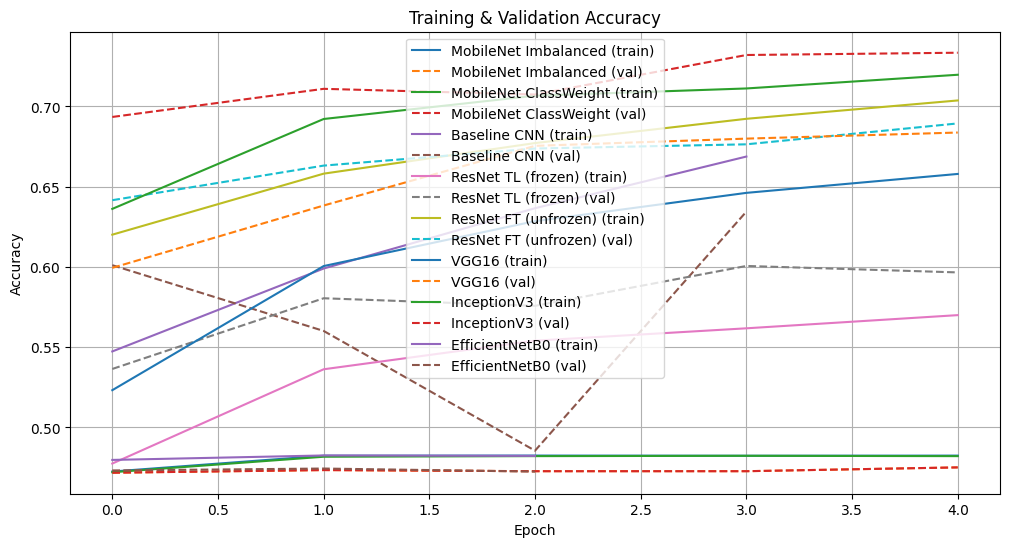

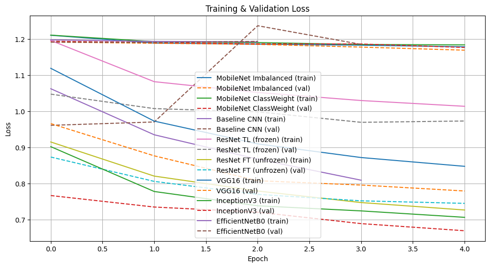

```python
# Collect histories
histories = {
    "MobileNet Imbalanced":   results_imbal["history"],
    "MobileNet ClassWeight":  results_bal["history"],
    "Baseline CNN":           history.history,          # CNN from scratch
    "ResNet TL (frozen)":     history_tl.history,       # ResNet transfer learning
    "ResNet FT (unfrozen)":   history_ft.history,       # ResNet fine-tuning
    "VGG16":                  hist_vgg16.history,
    "InceptionV3":            hist_incv3.history,
    "EfficientNetB0":         hist_efn.history,
}

def plot_history(histories, metric="accuracy", figsize=(12, 6)):
    plt.figure(figsize=figsize)
    for name, hist in histories.items():
        if metric in hist:
            plt.plot(hist[metric], label=f"{name} (train)")
        if f"val_{metric}" in hist:
            plt.plot(hist[f"val_{metric}"], linestyle="--", label=f"{name} (val)")
    plt.title(f"Training & Validation {metric.title()}")
    plt.xlabel("Epoch")
    plt.ylabel(metric.title())
    plt.grid(True)
    plt.legend()
    plt.show()

# Accuracy curves
plot_history(histories, metric="accuracy")

# Loss curves
plot_history(histories, metric="loss")
```

# **6. Augmentation**

For at least one model, re-train it using **data augmentation techniques**.

```python
augment = keras.Sequential(
    [
        layers.RandomFlip("horizontal"),
        layers.RandomRotation(0.08),
        layers.RandomZoom(0.1),
    ],
    name="augment",
)
```

```python
# Rebuild datasets
train_ds, val_ds, test_ds, class_names = make_datasets(DATA_DIR)
num_classes = len(class_names)

# Build baseline CNN (your earlier architecture)
baseline_aug = build_baseline_cnn(IMG_SIZE + (3,), num_classes)

# Early stopping
es_aug = keras.callbacks.EarlyStopping(
    monitor="val_loss",
    patience=3,
    restore_best_weights=True,
    verbose=1
)

# Train using the augmented training dataset
history_aug = baseline_aug.fit(
    train_ds,                 # contains normalization + augmentation
    validation_data=val_ds,   # contains only normalization
    epochs=5,
    callbacks=[es_aug],
    verbose=1
)
```

```
Found 42330 files belonging to 4 classes.
Using 33864 files for training.
Found 42330 files belonging to 4 classes.
Using 8466 files for validation.
1059/1059 ━━━━━━━━━━━━━━━━━━━━ 78s 57ms/step - accuracy: 0.5130 - loss: 1.1448 - val_accuracy: 0.5343 - val_loss: 1.0351
1059/1059 ━━━━━━━━━━━━━━━━━━━━ 71s 55ms/step - accuracy: 0.5837 - loss: 0.9728 - val_accuracy: 0.5750 - val_loss: 0.9838
1059/1059 ━━━━━━━━━━━━━━━━━━━━ 73s 56ms/step - accuracy: 0.6119 - loss: 0.9054 - val_accuracy: 0.4356 - val_loss: 1.5123
1059/1059 ━━━━━━━━━━━━━━━━━━━━ 73s 55ms/step - accuracy: 0.6368 - loss: 0.8609 - val_accuracy: 0.6160 - val_loss: 0.8702
1059/1059 ━━━━━━━━━━━━━━━━━━━━ 73s 56ms/step - accuracy: 0.6555 - loss: 0.8204 - val_accuracy: 0.6638 - val_loss: 0.7851
Restoring model weights from the end of the best epoch: 5.
```

```python
# Evaluate on the test set
test_loss, test_acc = baseline_aug.evaluate(test_ds, verbose=1)
print(f"\n[Baseline CNN (Augmented)] Test Accuracy: {test_acc:.4f} | Test Loss: {test_loss:.4f}")
```

```
133/133 ━━━━━━━━━━━━━━━━━━━━ 8s 36ms/step - accuracy: 0.6807 - loss: 0.7633

[Baseline CNN (Augmented)] Test Accuracy: 0.6681 | Test Loss: 0.7757
```

Describe the types of augmentations used (e.g., flipping, cropping, rotation) and how they affected performance.

The first augmentation used was layers.RandomFlip("horizontal"), which creates a mirror-large version of the X-ray by flipping it left to right. The second augmentation used was layers.RandomRotation(0.08), which randomly rotates the image by approximately ±8%. Lastly, the third augmentation was layers.RandomZoom(0.1), it zooms out of the photo by 10%.

# **7. Interpretability & Insights**

Reflect on which model performed best and why.

- Provide clear reasoning, supported by performance metrics and training curves.

Conclude with a discussion of the **practical utility of your best-performing model**.

- Who would benefit from using this model?
- In what types of real-world scenarios would your solution be useful?
- Radiologists and clinical imaging specialists might benefit from using this model, because the model can act as a decision-support tool, making it more efficiently for health practitioner to identify abnormal regions on chest X-rays during peak patient traffic.
- In settings with limited time and large patient turnover such as the ER, rapid screening is crucial. The model can help quickly differentiate between normal lungs, viral pneumonia, Covid-19 patterns etc.